[figure not shown]

[figure not shown]

[figure not shown]

# Informe de Resultados Red Multiambiental de Evaluación de híbridos de Maíz de Primera 2024/2025

# Introducción

El cultivo de maíz (*Zea mays*) es uno de los más importantes en los sistemas productivos de la región. La alta producción de biomasa de este cultivo genera un importante aporte de C al suelo. Además, su inclusión en la rotación disminuye la incidencia de enfermedades y plagas en otros cultivos.

El rendimiento de un cultivo (fenotipo) es función del resultado acumulativo de numerosos factores que inciden en la interacción entre la expresión del material genético del híbrido o cultivar (genotipo) y las condiciones en las cuales la planta crece (ambiente). Los ambientes difieren en la cantidad y calidad de recursos que están disponibles para las plantas (agua, nutrientes y radiación), y las plantas capturan y convierten dichos recursos en biomasa y órganos de interés comercial, según su carga genética, que a su vez es modulada por el ambiente (Yan y Kang, 2002).

Según el objetivo de mejoramiento, los genotipos pueden ser seleccionados para mejorar su adaptación a un amplio rango de condiciones ambientales o bien para condiciones más específicas. En este último caso, la adaptación sitio-específica de los genotipos se relaciona con el fenómeno denominado *interacción genotipo-ambiente* (**GA**), el cual se observa cuando la performance relativa de los fenotipos depende del ambiente en el que crecen (Malosetti et al., 2013).

La interacción **GA** reduce la asociación entre los valores fenotípicos y genotípicos, lo cual puede ocasionar que los genotipos seleccionados por su performance en un ambiente tengan tengan mal desempeño en otro. Es por ello que en presencia de fuerte interacción **GA**, gran parte del éxito productivo del cultivo de maiz es el resultado de la elección de los materiales más aptos para cada ambiente.

## Objetivos

- Resumir los datos de rendimiento de los genotipos de maiz evaluadas en la Red CREA RNSF de Ensayos Multiambientales durante la campaña 2024/25.
- Analizar estadísticamente los datos comparando los genotipos globalmente en toda la red en la campaña 2024/25.
- Explorar y describir los patrones de la interacción **GA** en la campaña 2024/25 en particular y considerando el conjunto de ambientes explorados en las distintas localidades y campañas.

# Metodología

## Sitios experimentales

Durante la campaña 2024/25 se llevaron adelante ensayos comparativos de rendimiento de genotipos de maiz de primera en 3 localidades del Norte de la Provincia de Santa Fe. Los sitios seleccionados para los ensayos en cada localidad corresponden a establecimientos productivos de miembros CREA de la Región Norte de Santa Fe. La distribución espacial e información de los ensayos se muestra en el siguiente mapa. A modo de referencia se incluye la ubicación de los ensayos de las campañas anteriores.

Mapa interactivo: se puede hacer zoom o mostrar/ocultar información de cada ensayo (Fecha de siembra, antecesor, densidad, fertilizacion, etc) haciendo haciendo clik sobre los puntos de la campaña 2024/25.

[interactive chart not shown]

Distribución espacial de las localidades incluidas en la campaña 2024/25 y anteriores

En cada sitio se establecieron ensayos comparativos de rendimiento (ECR) utilizando un diseño experimental sin réplicas con controles sistemáticos (Kempton, 1997). Los materiales fueron sembrados con espaciamiento entre surco (EES) de 52 cm en franjas de 4.16 m de ancho por entre 170 y 200 m de longitud.

## Condiciones climáticas

En la siguiente Figura se resumen las precipitaciones mensuales de la presente campaña así como la serie 1945-2020 registrada en la EEA INTA Reconquista.

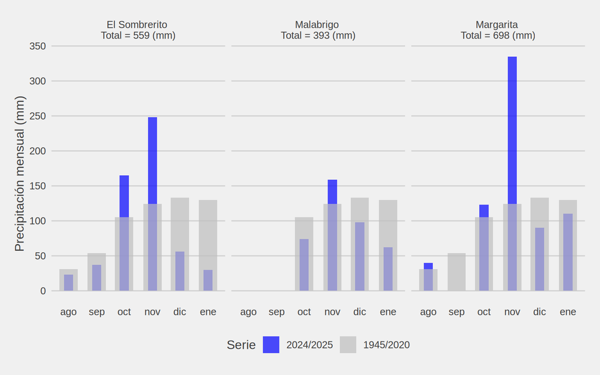

Precipitaciones mensuales totales por localidad durante la campaña 2024/25 y serie 1945/2020 del EEA INTA Reconquista

Al inicio y final de la campaña `El Sombrerito` tuvo precipitaciones menores al promedio, sobre todo al final del ciclo donde se las precipitaciones fueron menos de la mitad del historico de referencia. En los meses de octubre y noviembre casi duplicó el promedio

`Malabrigo` tuvo menores precipitaciones que el resto de las localidades con una distribución ligeramente más uniforme que `El Sombrerito`.

Finalmente en `Margarita` se registraron precipitaciones cercanas al promedio a excepción del mes de noviembre donde se registró casi el 50% de las precipitaciones de todo el ciclo.

En cuanto a la marcha del régimen térmico, en ninguna de las localidades se registraron heladas tardías. Hacia finales del ciclo, se registró un periódo de altas temperaturas sostenidas durante varios días.

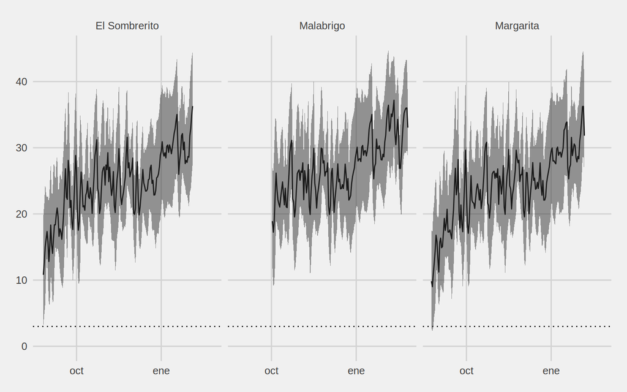

Temperaturas minimas, medias y máximas diarias por localidad durante la campaña 2024/25

## Genotipos

Los tratamientos evaluados en la campania 2024/25 fueron 27 genotipos. En la siguiente Tabla se indican las localidades en las que fueron evaluados.

Cultivares evaluadas y localidades en las que fueron incluidas

Semillero

Genotipo

Localidades

El Sombrerito

Malabrigo

Margarita

ACA 471 VT3PRO

ACA 476 TRECEPTA

ACA 477 TRECEPTA

ADV 8063 TRECEPTA

[figure not shown]

BRV 8380 PWU

DK 69-62 TRECEPTA

DK 72-10 VTPro4

XX1

XX2

XX3

[figure not shown]

DUO 2-35 PW

KM 13160 VIP3

KM 13916 VIP3

KWS 19-120 VIP3

NXM 5122 PWUE

NXM 7123 PW

NK 842 VIP3

NK 855 VIPT3

SYN 505 VIP3

NS 7626 VIP3CL

NX 7761 VT3PRO

NS 7765 VIP3

P 1804 PWUE

P 2021 PWUE

SPS 2615 VIP3

SPS 2743 VIP3

[figure not shown]

ST 9939-20 VIP3

El genotipo NK 842 VIP3 actuó como referencia o *check*, con más de una réplica por localidad. Para el análisis global se utilizaron los datos de todos los genotipos presentes en las tres localidades.

# Resultados

## Rendimiento testigo

Los rendimientos promedio por localidad de los genotipos utilizados como *check* o control se uestran en la sigueinte tabla:

Rendimiento seco medio y coeficiente de variación por localidad de los genotipos utilizados como *check*

| Localidad | media | CV |
| --- | --- | --- |
| El Sombrerito | 7764 | 2 |
| Malabrigo | 6023 | 12 |
| Margarita | 9959 | 5 |

La variabilidad observada en el control repetido fue más alta en `Malabrigo` indicando heterogeneidad en las condiciones experimentales dentro del sitio. En esta localidad se observó un gradiente de rendimientos consistente en dirección al orden de las parcelas por lo que los rendimientos fueron ajustados. A continuación se muestra el stand de plantas promedio logrado en las distintas localidades:

Stand de plantas logrado en cada localidad

| Localidad | Promedio | CV (%) |
| --- | --- | --- |
| El Sombrerito | 41250 | 7 |
| Malabrigo | 55000 | 5 |
| Margarita | 50593 | 7 |

El stand mostró baja variación dentro de las localidades, con CV en torno al 5-7%.

## Rendimientos por Localiad

La siguiente figura muestra los rendimientos medios por localidad. La línea continua representa el promedio en toda la campaña.

*Gráficos interactivos: se puede hacer zoom o mostrar/ocultar los grupos de datos haciendo doble-click en la leyenda.*

[interactive chart not shown]

Rendimiento seco promedio y desvío estándar por Localidad

Los rendimientos promedio de las localidades variaron entre 5800 y 10100 kg ha<sup>-1</sup>. Este aspecto determina el rango del índice ambiental explorado. Por otro lado, las parcelas con *checks* mostraron rendimientos en torno al rendimiento promedio de la localidad o rendimientos más altos como el caso de `El Sombrerito`.

## Rendimientos por Genotipo

En la siguiente figura se presentan los valores medios y desviaciones estándar de los rendimientos seco de los genotipos considerando la variabilidad entre localidades.

*Gráficos interactivos: se puede hacer zoom o mostrar/ocultar los grupos de datos haciendo doble-click en la leyenda.*

[interactive chart not shown]

Rendimientos medios y desvio estándar de los genotipos

En general todos los genotipos presentaron rendimientos medios a través de las localidades entre 5600 y 8300 kg ha<sup>-1</sup>. La amplitud de las barras de cada material representan las diferencias de variabilidad entre ambientes. Genotipos como `NXM 5122 PWUE`, `SPS 2743VIP3`, `ADV 8063 TRECEPTA`, Y `SPS 2615 VIP3` mostraron rendimiento promedio superior al general. Se observó mucha variabilidad en los rendimientos de `ACA 477 TRECEPTA`. Los hibridos `XX3` y `P 2021 PWUE` se caracterizaron por un mejor desvio con rendimientos similares al promedio.

## Rendimientos promedio y CV

En la siguiente tabla se presentan los promedios y $CV$ por `Genotipo` y `Localidad`, del rendimiento seco en kg/ha y base 100. Los genotipos están **ordenados en función del valor relativo promedio**. Los colores están ordenados en función del valor relativo de cada localidad.**

Los datos pueden descargarse de los siguientes enlaces: medias_CV_rend_real.xlsx

Los datos pueden descargarse de los siguientes enlaces: medias_CV_rend_aj.xlsx

### Tabla rendimiento y CV

Rendimiento seco medio ajustado (kg/ha) y coeficiente de variación por genotipo y localidad

[output not shown]

En general se observaron cambios en la posición relativa a traves de las localidades. En algunos casos, estos cambios fueron más grandes como por ejemplo `NK 855 VIPT3`, `P 1804 PWUE` (pasan de rendimiento relativo ligeramente superior a 100 a rendimientos relativos menores a 100).

### Gráfico

A continuación se presenta la relación entre los rendimientos promedio expresados en valores relativos y la estabilidad (indicada por el CV) de los genotipos a través de las localidades incluidas en la red durante la campaña 2024/25.

[interactive chart not shown]

Rendimiento relativo medio (en kg/ha) y CV (%) de los genotipos evaluados en la campaña 2024/25

Tomando el rendimiento y CV medios de la red (líneas punteadas), se observa que la mayoría de los hibridos tuvieron variacion de 15% o menores. Se destaca `NXM 5122 PWUE`, `SPS 2743 VIP3`, `ADV 8063 TRECEPTA` y `SPS 2615 VIP3`, por tener rendimiento relativo casi 10% superiores y baja variabilidad. Mientras que `ACA 477 TRECEPTA` mostró un rendimientos ligeramente inferior al promedio y la mayor variabilidad.

## Diferencias entre genotipos

Los resultados del análisis de la varianza (ANOVA) del modelo ajustado se presentan a continuación.

Tabla de Análisis de la Varianza del modelo lineal mixto

|  | gl | F | Valor p |
| --- | --- | --- | --- |
| (Intercept) | 1 | 11,838.63 | 0.00000 |
| Localidad | 2 | 313.74 | 0.00000 |
| Genotipo | 20 | 1.67 | 0.08223 |

Rendimientos intervalos de confianza 90% ajustados por el modelo

|  | Rend. medio | Error estándar | gl | LI IC90 | LS IC90 | grupo |
| --- | --- | --- | --- | --- | --- | --- |
| NXM 5122 PWUE | 8351 | 321 | 40 | 7811 | 8891 | a |
| SPS 2743 VIP3 | 8145 | 321 | 40 | 7605 | 8685 | ab |
| ADV 8063 TRECEPTA | 8104 | 321 | 40 | 7564 | 8644 | ab |
| SPS 2615 VIP3 | 8020 | 321 | 40 | 7480 | 8560 | ab |
| BRV 8380 PWU | 7979 | 321 | 40 | 7439 | 8519 | ab |
| NS 7626 VIP3CL | 7924 | 321 | 40 | 7384 | 8464 | abc |
| DUO 2-35 PW | 7810 | 321 | 40 | 7270 | 8350 | abcd |
| P 1804 PWUE | 7778 | 321 | 40 | 7238 | 8318 | abcd |
| NK 855 VIPT3 | 7765 | 321 | 40 | 7225 | 8305 | abcd |
| NK 842 VIP3 | 7756 | 321 | 40 | 7216 | 8296 | abcd |
| NX 7761 VT3PRO | 7659 | 321 | 40 | 7119 | 8199 | abcde |
| NXM 7123 PW | 7632 | 321 | 40 | 7092 | 8172 | abcde |
| ST 9939-20 VIP3 | 7552 | 321 | 40 | 7012 | 8092 | bcde |
| XX3 | 7417 | 321 | 40 | 6877 | 7957 | bcdef |
| P 2021 PWUE | 7417 | 321 | 40 | 6877 | 7957 | bcdef |
| ACA 476 TRECEPTA | 7399 | 321 | 40 | 6859 | 7939 | bcdef |
| XX2 | 7190 | 321 | 40 | 6650 | 7730 | cdef |
| KM 13916 VIP3 | 7178 | 321 | 40 | 6638 | 7718 | cdef |
| ACA 471 VT3PRO | 7121 | 321 | 40 | 6581 | 7661 | def |
| KWS 19-120 VIP3 | 6971 | 321 | 40 | 6431 | 7511 | ef |
| KM 13160 VIP3 | 6766 | 321 | 40 | 6226 | 7306 | f |

El cuadro anterior representa el ranking de genotipos ordeandos por el rendimiento global para la zona de influencia de la Red. El rendimiento medio representa la mejor estimación global del rendimiento de cada genotipo para la región en general a partir de la información obtenida en el presente ensayo. Este valor estimado se acompaña de los límites de un intervalo de confianza (LI IC90 y LS IC90) los cuales representan la región donde se encuentra el verdadero valor del rendimiento.

Considerando la red globalmente, el ranking de materiales muestra diferencias entre `NXM 5122 PWUE` respecto del grupo liderado por `ST 9939-20 VIP3`, con diferencias de 800 kg o más. Tambien el grupo de `SPS 2743 VIP3` a `ACA 476 TRECEPTA` se diferenció el grupo liderado por `XX2`.

## Interacción **GA**

### Campaña actual

Las diferencias de los rendimientos medios de cada localidad resumen la heterogeneidad de condiciones ambientales a las cuales fueron sometidos los genotipos evaluados. Utilizando esta información se construye un índice ambiental (`IA`) que se utiliza para modelar la interacción genotipo x ambiente a partir de rendimientos de cada genotipo y ambiente. A continuación la tabla de ANOVA del modelo Finlay.

Tabla de ANOVA del modelo de regresión para la interacción GxA

| Fuente | gl | SC | CM | F | Valor p |
| --- | --- | --- | --- | --- | --- |
| Localidad | 2 | 193679269.81 | 96839634.90 | 643.40 | <0.0001 |
| Genotipo | 20 | 10320919.71 | 516045.99 | 3.43 | 0.0041 |
| Genotipo:IA | 20 | 9336036.05 | 466801.80 | 3.10 | 0.0074 |
| Residuals | 20 | 3010260.14 | 150513.01 |  |  |

Según este análisis, se detecta interacción significativa entre los materiales evaluados y el índice ambiental (p = 0.007). Esto implica que, las diferencias de *sensibilidad* observadas, es decir la heterogeneidad de las pendientes de la relación `IA` y rendimiento fueron consistentes debido principalmente al rango valores de IA explorados.

La siguiente figura muestra las gráficas correspondientes a las normas de reacción a los cambios del `IA` en relación a la respuesta promedio (recta 1:1).

*Gráficos interactivos: se puede hacer zoom o mostrar/ocultar los grupos de datos haciendo doble-click en la leyenda. Por defecto se muestra el primer genotipo, pero haciendo click o doble-click sobre los nombres de los genotipos se pueden agregar/remover rectas para comparar.*

[interactive chart not shown]

Respuesta diferencial de cada Genotipo a los cambios del IA

Las pendientes ($\beta$) de las rectas (línea sólida de color) representan la sensibilidad de cada genotipo a la calidad del ambiente caracterizada por el rendimiento medio de la localidad. La sensibilidad promedio (línea punteada) representa la respuesta general de todos los genotipos. Para un genotipo cualquiera, si el valor de la pendiente es $\beta_i > 1$, el genotipo en cuestión tiene mayor sensibilidad a los cambios de calidad del ambiente (a mayor calidad ambiental, mayor rendimiento, y vice versa). En cambio si $\beta_i < 1$, entonces el genotipo es menos sensible y tendría mejores respuestas en ambientes malos y respuestas inferiores al promedio en ambientes buenos. Las diferencias entre las pendientes de los distintos genotipos representa la interacción **GA**.

A modo descriptivo los valores estimados de los $\beta$ para algunos genotipos, como por ejemplo `ST 9939-20 VIP3` mostraron pendientes positivas 25% mayores al promedio general. En el otro extremo, `XX3`, `KM 13160 VIP3`, y `P 2021 PWUE` fueron los materiales con menor sensibilidad (pendientes 25% menores a 1). No obstante, `BRV 8380 PWU`, `NXM 5122 PWUE`, `NXM 7123 PW`, y `ST 9939-20 VIP3` tuvieron estimaciones por encima de la recta 1:1 (mayor sensibildiad) y `KM 13160 VIP3`, `P 2021 PWUE` y `XX3` con menor sensibilidad.

El siguiente gráfico muestra la relación entre las pendientes estimadas y los rendimientos medios de cada genotipo.

[interactive chart not shown]

Coeficiente de sensibilidad vs rendimiento medio de los genotipos a través de las localidades

Se observa que entre los materiales con mayores rendimiento promedio los valores de sensibilidad fluctuaron entre 0.75 y 1.2.

### Últimas campañas

Tabla de ANOVA del modelo de regresión para la interacción GxA últimas 3 campañas.

| Fuente | gl | SC | CM | F | Valor p |
| --- | --- | --- | --- | --- | --- |
| Localidad | 4 | 267544533.58 | 66886133.39 | 117.88 | <0.0001 |
| Genotipo | 4 | 6358405.34 | 1589601.33 | 2.80 | 0.0522 |
| Genotipo:IA | 5 | 22881157.77 | 4576231.55 | 8.07 | 2e-04 |
| Residuals | 21 | 11915389.45 | 567399.50 |  |  |

Penidentes estimadas últimas 3 campañas.

| Genotipo | Beta | Error estándar | gl | LI IC90 | LS IC90 |
| --- | --- | --- | --- | --- | --- |
| BRV 8380 PWU | 1.09 | 0.09 | 25 | 0.91 | 1.28 |
| ACA 476 TRECEPTA | 1.03 | 0.09 | 25 | 0.84 | 1.21 |
| SPS 2743 VIP3 | 0.94 | 0.09 | 25 | 0.75 | 1.12 |
| P 1804 PWUE | 0.79 | 0.09 | 25 | 0.60 | 0.97 |
| P 2021 PWU | 0.78 | 0.09 | 25 | 0.59 | 0.96 |

Según la tabla anterior se observa que, las estimaciones de sensibilidad de `P 1804 PWUE` y `P 2021 PWU` fueron por debajo de la norma promedio (intervalo de confianza no contiene al 1). En cambio para el resto de los genotipos la sensibilidad estimada fue en torno al promedio.

[interactive chart not shown]

Respuesta diferencial de cada Genotipo a los cambios del IA ultimas 3 campañas

Según el gráfico anterior se observa la menor pendiente de `P 1804 PWUE` y `P 2021 PWU`, y mayor pendiente de `BRV 8380 PWU`.

## Humedad de cosecha

A continuación se presenta la duración del ciclo del cultivo para cada localidad y la humedad a cosecha lograda.

Humedad a cosecha de cada gentoipo y duración ciclo por localidad

| Genotipo | Localidad (Duración ciclo) El Sombrerito (162 días) | Localidad (Duración ciclo) Malabrigo (147 días) | Localidad (Duración ciclo) Margarita (166 días) |
| --- | --- | --- | --- |
| ACA 471 VT3PRO | 9.1 | 11.0 | 11.8 |
| ACA 476 TRECEPTA | 9.2 | 11.0 | 13.0 |
| ADV 8063 TRECEPTA | 9.3 | 11.5 | 11.4 |
| BRV 8380 PWU | 9.1 | 11.0 | 12.9 |
| DK 69-62 TRECEPTA | 9.0 | — | — |
| DK 72-10 VTPro4 | 8.9 | — | — |
| DUO 2-35 PW | 10.1 | 11.3 | 14.2 |
| KM 13160 VIP3 | 10.0 | 11.6 | 13.1 |
| KM 13916 VIP3 | 9.8 | 11.4 | 13.5 |
| KWS 19-120 VIP3 | 10.0 | 11.7 | 14.9 |
| NK 842 VIP3 | 9.8 | 11.3 | 12.8 |
| NK 855 VIPT3 | 9.1 | 11.3 | 14.9 |
| NS 7626 VIP3CL | 9.7 | 11.5 | 12.7 |
| NX 7761 VT3PRO | 9.9 | 11.5 | 15.4 |
| NS 7765 VIP3 | 9.8 | — | — |
| NXM 5122 PWUE | 9.6 | 11.2 | 13.4 |
| NXM 7123 PW | 8.9 | 10.8 | 14.1 |
| P 1804 PWUE | 9.1 | 11.1 | 12.2 |
| P 2021 PWUE | 9.7 | 11.3 | 14.7 |
| SPS 2615 VIP3 | 9.3 | 11.1 | 13.1 |
| SPS 2743 VIP3 | 9.2 | 11.5 | 13.3 |
| ST 9939-20 VIP3 | 9.3 | 11.7 | 14.3 |
| SYN 505 VIP3 | 9.7 | — | — |
| XX2 | 8.9 | 11.3 | 11.9 |
| XX3 | 9.5 | 11.1 | 12.1 |
| ACA 477 TRECEPTA | — | 11.0 | 15.5 |
| XX1 | — | 11.2 | 12.3 |

Los datos pueden descargarse del siguiente enlace: tabla_humedad.xlsx

# Consideraciones finales

En general se observó una moderada variabilidad de los rendimientos de cada genotipo a través de las distintas localidades evaluadas y baja heterogeneidad de respuesta dentro de cada localidad reflejada por los testigos. A nivel global las diferencias se detectaron diferencias mayores a 800 kg ha<sup>-1</sup> entre `NXM 5122 PWUE` y el grupo encabezado por `ST 9939-20 VIP3`.

En el estudio de la interacción **GA** de la campaña actual se detectó diferencias significativas respecto al patrón de respuesta promedio, principalmente debido al rango de indice ambiental explorado. Los genotipos `BRV 8380 PWU`, `NXM 5122 PWUE`, `NXM 7123 PW`, y `ST 9939-20 VIP3` pendientes significativamente superiores a 1 (mayor sensibildiad) y mientras que `KM 13160 VIP3`, `P 2021 PWUE` y `XX3` mostraron menor sensibilidad.

En el análisis combinado los datos de las últimas campañas se observó que los genotipos analizados mostraron heterogeneidad de pendientes al 10%, y se observaron algunas diferencias en los patrones siendo `P 2021 PWU` y `P 1084 PWUE` los menos sensibles.

# Agradecimientos

- A las empresas semilleras: A.C.A., Advanta, Brevant, Dekalb, Duo Semillas, KWS, MacroSeed, Nidera, NK, Pioneer, SPS, y Stine, por haber confiado un año más en nuestra zona y en la utilidad de los Ensayos Comparativos de Rendimiento.
- A las Empresas CREA de la Región Norte de Santa Fe que año tras año realizan el esfuerzo de siembra conducción y cosecha de estas macro parcelas en sus establecimientos, dedicando personal tiempo y recursos para tal fin.
- A las empresas Extra CREA – Faccioli Diego y Larrauri Maria Inmaculada por realizar el esfuerzo de siembra conducción y cosecha de estas macro parcelas en sus establecimientos, dedicando personal, tiempo y recursos para tal fin.

# Apéndice

## Análisis estadístico

### Rendimientos testigos

La información proveniente de las franjas testigo repetidas se utilizó para evaluar la variación dentro de las localidades y la existencia de tendencia espacial de los rendimientos según su ubicación en el experimento. Para esto último, en cada localidad se ajustaron modelos lineales de los rendimientos en función del orden de la parcela:

$$y_{i} = \beta_0 + \beta_1X_i + e_{i}$$

donde: $y_{i}$ representa la respuesta del testigo en la parcela $i$, $X_i$ es el número de posición de la parcela en el experimento, y $\beta_0$ y $\beta_1$ coeficientes de regresión.

### Estadísticas descriptivas

Se calcularon estadísticas de resumen y gráficos descriptivos por genotipo y localidad para la variable respuesta rendimiento seco (kg ha<sup>-1</sup>).

El promedio de cada genotipo en la red se calculó utilizando la siguiente expresión:

$$\bar{y}_i = \dfrac{\sum y_{ij}}{n_i}$$

donde: $\bar{y}_i$ es el rendimiento medio del genotipo $i$, $y_{ij}$ es el rendimiento del genotipo $i$ en la localidad $j$ y $n_i$ es el número de localidades donde fue evaluado el genotipo $i$. En aquellos casos donde se contó con más de una franja por localidad, los datos fueron promediados dentro de cada localidad. Así mismo el coeficiente de variación ($CV$) de cada genotipo en la red se calculó mediante la siguiente expresión:

$$CV_{{y}_i} = \dfrac{s_{y_i}}{\bar{y}_i} \times 100$$

donde: $\bar{y}_i$ es el rendimiento medio del genotipo $i$ y $s_{y_{i}}$ es el desvío estándar de los rendimientos del genotipo $i$ a través de las localidades:

$$s_{y_i} = \sqrt{\dfrac{\sum \left(y_{ij} - \bar{y}_i \right)^2}{n_i -1}}$$

Las estadísticas anteriores se expresaron en valores absolutos y relativos al promedio de la localidad.

### Diferencias de rendimiento

$$y^*_{ij} = \mu + \tau_i + \rho_j + l_j + e_{ij}$$

donde: $y^*_{ij}$ representa la respuesta del genotipo $i$ sembrado en la localidad $j$, corregido por efecto de la posición de la parcela en caso necesario; $\mu$ es la media general de los ensayos de la red, $\tau_i$ es efecto o diferencia del genotipo $i$ respecto a la media general del ensayo, $\rho_i$ es efecto de la relación stand de plantas y rendimiento en la localidad $j$, $l_j$ el efecto de la localidad $j$, y $e_{ij}$ el error experimental asociado al genotipo $i$ sembrado en la localidad $j$. Se asume que $l_j$ como $e_{ij}$ son independientes y tienen distribución normal con media 0 y varianza $\sigma^2_l$ y $\sigma^2_e$.

Las diferencias de rendimiento entre genotipos se determinaron mediante la prueba de comparaciones múltiples de Tukey, considerando un nivel de significancia de 10%.

### Análisis interacción genotipo x ambiente

Para explorar los patrones de interacción **GA** se utilizó el procedimiento de regresión sobre la media (Finlay y Wilkinson, 1963)

La heterogeneidad ambiental explorada por los genotipos considerados en la red se caracterizó mediante los rendimientos medios de cada `Localidad`. Esta covariable denominada **Índice Ambiental** (`IA`) fue utilizada para modelar la interacción **GA** a partir del siguiente modelo:

$$y_{ij} = \mu_i + \beta_i X_j + e_{ij}$$

donde: $y_{ij}$ es el rendimiento del genotipo $i$ en el ambiente o localidad $j$, $\mu_i$ es la ordenada al origen de cada genotipo, $X_j$ el índice ambiental de la localidad $j$, y $\beta_i$ la pendiente o sensibilidad del genotipo $i$ a los cambios del `IA`.

Según este modelo, $\mu_i$ representa el comportamiento de los genotipos en el ambiente promedio y los coeficientes $\beta_i$ la sensibilidad de los `Genotipos` a la calidad del ambiente caracterizada por el rendimiento medio de la localidad. Entonces, si la interacción **GA** es significativa representa la heterogeneidad de respuestas, i.e. $\beta$ distintos para los genotipos. El valor de $\beta$ indica la sensibilidad el genotipo a los cambios de calidad del ambiente. Si $\beta_i > 1$ indica que el genotipo $i$ tiene una respuesta mayor al promedio (a mayor calidad ambiental, mayor rendimiento), en cambio si $\beta_i < 1$, entonces el genotipo responde menos.

Número de genotipos presentes en todas las localidades de las últimas campañas

| Campañas | Número de genotipos |
| --- | --- |
| 2024/25 | 21 |
| 2023/24, 2024/25 | 12 |
| 2022/23, 2023/24, 2024/25 | 5 |
| 2021/22, 2022/23, 2023/24, 2024/25 | 2 |
| 2020/21, 2021/22, 2022/23, 2023/24, 2024/25 | 1 |
| 2019/20, 2020/21, 2021/22, 2022/23, 2023/24, 2024/25 | 0 |
| 2018/19, 2019/20, 2020/21, 2021/22, 2022/23, 2023/24, 2024/25 | 0 |
| 2017/18, 2018/19, 2019/20, 2020/21, 2021/22, 2022/23, 2023/24, 2024/25 | 0 |
| 2016/17, 2017/18, 2018/19, 2019/20, 2020/21, 2021/22, 2022/23, 2023/24, 2024/25 | 0 |

## Software

Los datos fueron procesados utilizando el software estadístico R versión 4.1 (R Core Team, 2021) y los paquetes `nlme` (Pinheiro et al., 2018), `emmeans` (Lenth, 2019), `tidyverse` (Wickham, 2017) y `plotly` (Sievert, 2020).

# Bibliografía

Finlay, K. W., and Wilkinson, G.N. (1963). The analysis of adaptation in a plant-breeding programme. Aust. J. Agric. Res. 14, 742–754.

Kempton, R.A. (Ed) (1997). Statistical methods for plant variety evaluation. Plant breeding series. Chapman & Hall, London. pp. 191.

Lenth, R. (2019). emmeans: Estimated Marginal Means, aka Least-Squares Means. R package version 1.3.3. https://CRAN.R-project.org/package=emmeans

Malosetti, Marcos, Jean-Marcel Ribaut, and Fred A. van Eeuwijk. 2013. “The Statistical Analysis of Multi-Environment Data: Modeling Genotype-by-Environment Interaction and Its Genetic Basis.” Frontiers in Physiology 4 (March). doi:10.3389/fphys.2013.00044.

Piepho, H.P., C. Richter, J. Spilke, K. Hartung, A. Kunick, and H. Thöle. 2011. Statistical aspects of on-farm experimentation. Crop and Pasture Science 62(9): 721.

Pinheiro J, Bates D, DebRoy S, Sarkar D, R Core Team (2018). *nlme: Linear and Nonlinear Mixed Effects Models*. R package version 3.1-137, URL: https://CRAN.R-project.org/package=nlme.

R Core Team (2021). R: A language and environment for statistical computing. R Foundation for Statistical Computing, Vienna, Austria. URL https://www.R-project.org/.

Sievert, C. (2020) Interactive Web-Based Data Visualization with R, plotly, and shiny. Chapman and Hall/CRC Florida.

Wickham, H. (2017). tidyverse: Easily Install and Load the ‘Tidyverse’. R package version 1.2.1. https://CRAN.R-project.org/package=tidyverse

Yan, W.; Kang, M. S. (2002). GGE Biplot Analysis: A Graphical Tool for Breeders, Geneticists, and Agronomists. 1st edition. CRC Press. pp. 288.